# report

##### relationship between rm and medv

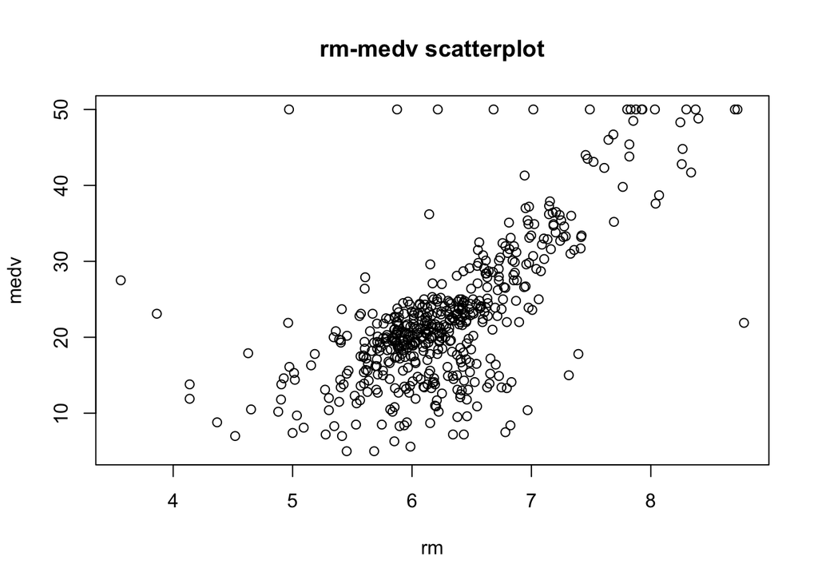

```r
rm = Boston$rm
medv = Boston$medv
plot(rm, medv, xlab="rm", ylab="medv", main="rm-medv scatterplot")
```

When rm increases, we can observe an increase in medv as well. These two variables have a positive correlation.

```r
cor(rm, medv)
```

```
## [1] 0.6953599
```

##### relationship between indus and nox

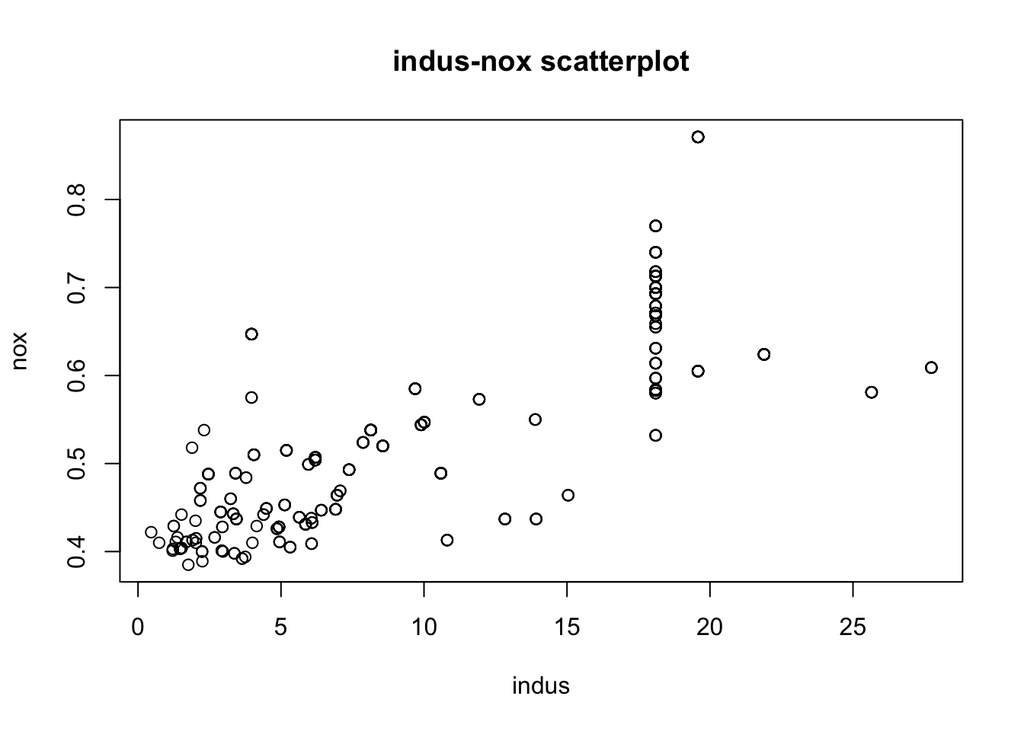

```r
indus = Boston$indus
nox = Boston$nox
plot(indus, nox, xlab="indus", ylab="nox", main="indus-nox scatterplot")
```

When indus increases, we can observe an increase in nox as well. These two variables have a positive correlation.

```r
cor(indus, nox)
```

```
## [1] 0.7636514
```

#### (c) Are any of the predictors associated with per capita crime rate? If so, explain the relationship.

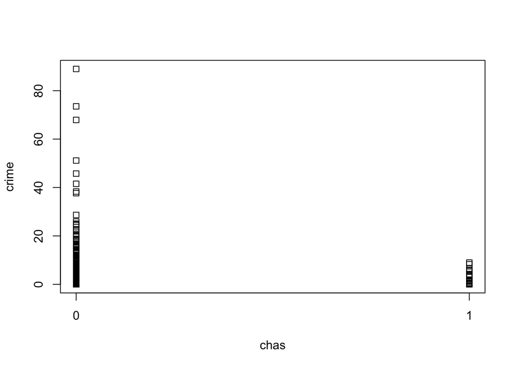

```r
crim = Boston$crim
chas = Boston$chas

stripchart(crim ~ factor(chas), xlab="chas", ylab="crime" ,vertical=TRUE)
```

It can be seen that the crime rate per capita is significantly higher in the case where it is not located at the boundary of the river than in the case where it is located at the boundary of the river.

#### (d) Do any of the census tracts of Boston appear to have particularly high crime rates? Tax rates? Pupil-teacher ratios? Comment on the range of each predictor.

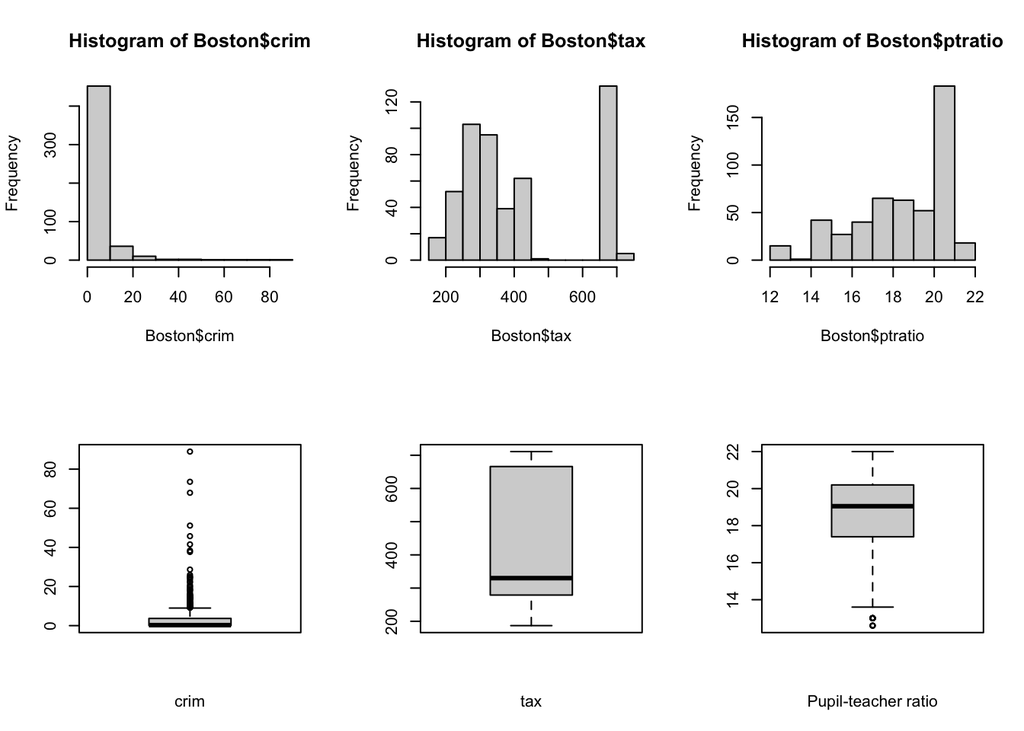

```r
par(mfrow=c(2,3))

hist(Boston$crim)
hist(Boston$tax)
hist(Boston$ptratio)

boxplot(Boston$crim, xlab="crim")
boxplot(Boston$tax, xlab="tax")
boxplot(Boston$ptratio, xlab="Pupil-teacher ratio")
```

d-1) crime rate  
Most cities have crime rates between 0 and 10. Most of the data is skewed to the left of the histogram. This variable has many outliers. range)

```r
crim_range <- range(Boston$crim)
crim_range
```

```
## [1]  0.00632 88.97620
```

d-2) Tax rate there is no outlier. range)

```r
tax_range <- range(Boston$tax)
tax_range
```

```
## [1] 187 711
```

d-3) Pupil-teacher ratios  
The data range from 12.6 to 22.0. range)

```r
ptr_range <- range(Boston$ptratio)
ptr_range
```

```
## [1] 12.6 22.0
```

#### (e) How many of the census tracts in this data set bound the Charles river?

```r
table(Boston$chas)
```

```
##
##   0   1
## 471  35
```

There are 35 census tracts that set bound the Charles River.

#### (f) What is the median pupil-teacher ratio among the towns in this data set?

```r
median(Boston$ptratio)
```

```
## [1] 19.05
```

The median pupil-teacher ratio among the towns is 19.05.